# Initial Setup for RSTPY Lab

### Objective:

Setup the initial Lab environmnet.

- Install Visual Studio Code on the Windows Jumphost
  - Download Visual Studio Code:

    Open Chrome browser and in the search bar, type `vscode download`

    The first search link should take you to the following site:

    [VSCode Download Page `https://code.visualstudio.com/download`](https://code.visualstudio.com/download)

    Click on the Windows logo to download the installer:

[figure not shown]

    Once downloaded, Click to access the downloads folder:

[figure not shown]

  - Run the VSCode Setup Installer:

[figure not shown]

  - Do the VS Code Onboarding:

    Select the Theme to your preference

    When done, click on `Mark Done`
  - Install the following VS Code Extension on Windows:
    - Remote SSH

    In the left hand `Activity Bar`, click on the `Extensions` icon:

[figure not shown]

    In the `Extensions` Search for `Remote SSH` Extension by Microsoft. We will need it to connect to the Linux machine `centos1`

[figure not shown]

    Click on the Install Button as shown above.

    Once the extension is installed, the `Remote Explorer` icon should become available in the `Activity Bar`

[figure not shown]

    Click on the `Remote Explorer`, then Click on the `+` to add a connection to the Linux host

[figure not shown]

    In the `Enter SSH Connection Command` dialog box, enter `root@centos1` to connect to the Linux server where `Python` and `git` are installed. We will use that machine's environment to do our programming. VS Code will install a mini server on the Linux machine so that we can have a VS Code window running on the Windows `Jumphost` that connects to the Linux `centos1`.

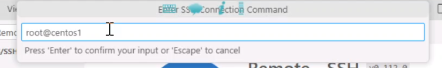

    In the `Select SSH configuration file to update` dialog, select the config file in the .ssh folder in the user's home directory as shown below:

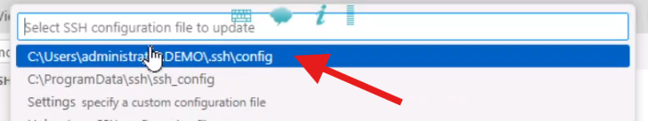

    At the bottom right of the VS Code window, you should see a pop-up, Click on `Connect`

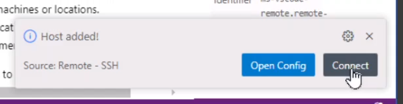

    In the `Select the platform of the remote host "centosl"` dialog, select `Linux`.

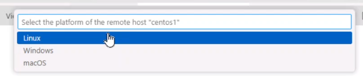

    Confirm the fingerprint of the `centos1` host by clicking on `Continue`:

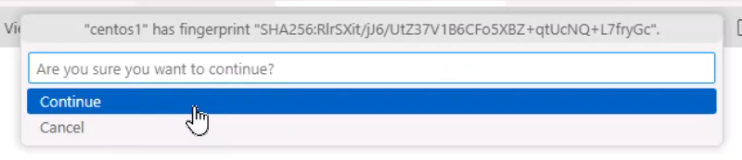

    In the `Enter password for root@centosl` dialog box, enter the password for the root user `Netapp1!`

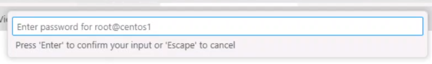

    At the bottom of the VS Code window, note that you are now connected to `centos1`

[figure not shown]

  - Set up Public Key Authentication

    In the `centos1` connected VS Code window, Press `` CTRL+` `` to open a terminal on the linux host. Note that it is the `back tick` character and not a `single qoute` character. Alternatively, you can click on `Terminal` from the `View` Menu.

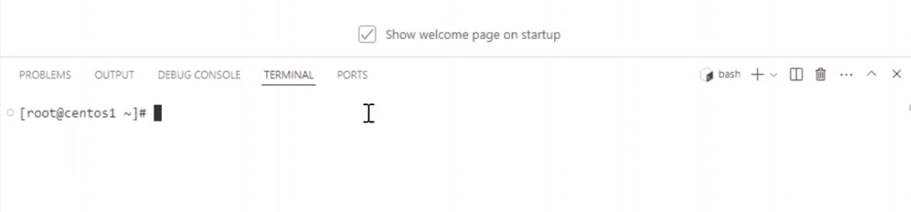

    In the terminal, type `ssh-keygen` to generate a public/private key pair for the root user on the linux machine. This will also create the required `.ssh` directory with the correct permissions. We will copy the Windows administrator's public key to the `authorized_keys` file in this `.ssh` folder to allow for passwordless, public key authentication from the Windows machine.

    For the location of the key file, accept th default location and use an empty passphrase as shown below:

[figure not shown]

    On the Windows `Jumphost`, open a powershell window, and type `ssh-keygen` as we did in the Linux terminal through VS Code. Again accept the default location for the key files and and empty passphrase.

[figure not shown]

    We will then copy the public key to the `authorized_keys` file on the linux host. To do this, cd to the `.ssh` folder on the `Jumphost` powershell window and run the following command:

    ```
    scp .\id_rsa.pub root@centos1:~/.ssh/authorized_keys
    ```

    Accept the fingerprint displayed.

[figure not shown]

    Going back the the VS Code window connected to the `centos1`, in the terminal, edit the `/etc/ssh/sshd_config` file to allow Public Key authentication.
    - Edit /etc/ssh/sshd_config on `centos1` to allow PubkeyAuthentication
      - `vi /etc/ssh/sshd_config`
      - in vi, Enter the keystrokes exactly: `/Pubkey ENTER yy p x :wq ENTER`
        - Explanation of the keystrokes:

          Search for `Pubkey` by typing: `/Pubkey` followed by `ENTER` key

          Yank the line : `yy`

          Paste the line: `p`

          Delete the comment `#` character at the beginning of the line by pressing: `x`

          Save and exit vi `:wq Enter`
    - Restart sshd

      `systemctl restart sshd.service`
  - You can move the terminal to a full pane by doing the following:

    Click on the Terminal, then select `Move Terminal to Editor Area`

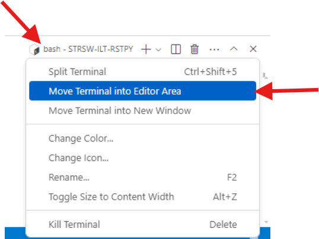